# INN_Learner_Notebook_Full_code_version_(1)

## Data Preprocessing

### Train-validation-test Split

```python
X = df.drop(['Exited'],axis=1) # X values
y = df['Exited'] # Exited
```

```python
# Splitting the dataset into the Training and Dummy set.
X_train,X_dummy,y_train,y_dummy = train_test_split(X,y,test_size=0.2,random_state=1,stratify=y,shuffle=True) ## using train_test_split to create train test objects
X_test,X_val,y_test,y_val = train_test_split(X_dummy,y_dummy,test_size=0.5,random_state=1,stratify=y_dummy,shuffle=True) ## using train_test_split to create train test objects
```

Here we created training, validation and testing set in order to have power to check our model on validation set first and then final check on test set

```python
print("X shape")
print(X_train.shape, X_val.shape, X_test.shape)  ## printing X shape
print("*"*200)
print("Y shape")
print(y_train.shape, y_val.shape, y_test.shape) ## Printing y shapes
```

```
X shape
(8000, 10) (1000, 10) (1000, 10)
Y shape
(8000,) (1000,) (1000,)
```

We can see we have 8000 rows and 10 columns in train set, while we have 1000 rows and 10 columns in validation and test set

### Dummy Variable Creation

```python
# Encoding Geography variable
X_train = pd.get_dummies(X_train, columns=["Geography","Gender"],drop_first=True) ## encode Geography and Gender in train set
X_test = pd.get_dummies(X_test, columns=["Geography","Gender"],drop_first=True)   ## encode Geography and Gender in test set
X_val = pd.get_dummies(X_val, columns=["Geography","Gender"],drop_first=True)     ## encode Geography and Gender in validation set
```

### Data Normalization

Since we know there are multiple numerical colums which are on various different scale, hence scaling them now

```python
# defining the list of columns to normalize
cols_list = ["CreditScore","Age","Tenure","Balance","EstimatedSalary"]

# creating an instance of the standard scaler
sc = StandardScaler()

X_train[cols_list] = sc.fit_transform(X_train[cols_list]) ## Code to normalize the train data
X_val[cols_list] = sc.transform(X_val[cols_list])    ## code to normalize validation data
X_test[cols_list] = sc.transform(X_test[cols_list])    ## Code to normalize the test data
```

## Model Building

### Model Evaluation Criterion

**Model can make wrong predictions as:**

Predicting a customer will exit but in reality the customer will not exit - Loss of resources on the customer to try to not let him exit Predicting a customer will not exit but in reality the customer was going to exit - Loss of opportunity

Which case is more important?

Losing a potential customer by predicting that the it will not exit , but in reality it will exit is more important How to reduce this loss i.e need to reduce False Negatives?

Bank would want Recall to be maximized, greater the Recall higher the chances of minimizing false negatives. Hence, the focus should be on increasing Recall or minimizing the false negatives.

```python
def make_confusion_matrix(actual_targets, predicted_targets):
    """
    To plot the confusion_matrix with percentages

    actual_targets: actual target (dependent) variable values
    predicted_targets: predicted target (dependent) variable values
    """
    cm = confusion_matrix(actual_targets, predicted_targets)
    labels = np.asarray(
        [
            ["{0:0.0f}".format(item) + "\n{0:.2%}".format(item / cm.flatten().sum())]
            for item in cm.flatten()
        ]
    ).reshape(cm.shape[0], cm.shape[1])

    plt.figure(figsize=(6, 4))
    sns.heatmap(cm, annot=labels, fmt="")
    plt.ylabel("True label")
    plt.xlabel("Predicted label")
```

Lets create two blank tables that will collect recall values of our models that we build

```python
train_metric_df = pd.DataFrame(columns=["recall"])
valid_metric_df = pd.DataFrame(columns=["recall"])
```

### Neural Network with SGD Optimizer

```python
backend.clear_session()
#Fixing the seed for random number generators so that we can ensure we receive the same output everytime
np.random.seed(1)
random.seed(1)
tf.random.set_seed(1)
```

```python
#Initializing the neural network
model_0 = Sequential()
# Adding the input layer with 64 neurons and relu as activation function
model_0.add(Dense(64, activation='relu', input_dim = X_train.shape[1]))
# add hidden layer with 16  neurons and sigmoid as activation
model_0.add(Dense(16, activation='sigmoid'))
# output layer with 1 neuron giving us output iwth sigmoid activation
model_0.add(Dense(1, activation = 'sigmoid'))
```

```python
#Complete the code to use SGD as the optimizer.
optimizer = tf.keras.optimizers.SGD(learning_rate=0.001)

metric = keras.metrics.Recall() ## using recall as metrics
```

```python
##Compling model

model_0.compile(loss='binary_crossentropy',optimizer=optimizer,metrics=[metric])
```

```python
model_0.summary()  ## getting summary
```

```
Model: "sequential"
_________________________________________________________________
 Layer (type)                Output Shape              Param #
=================================================================
 dense (Dense)               (None, 64)                768

 dense_1 (Dense)             (None, 16)                1040

 dense_2 (Dense)             (None, 1)                 17

=================================================================
Total params: 1,825
Trainable params: 1,825
Non-trainable params: 0
_________________________________________________________________
```

```python
# Fitting the ANN

history_0 = model_0.fit(
    X_train, y_train,
    batch_size=64,
    validation_data=(X_val,y_val),
    epochs=100,    ## Complete the code to specify the number of epochs
    verbose=1
)
```

#### Loss Function

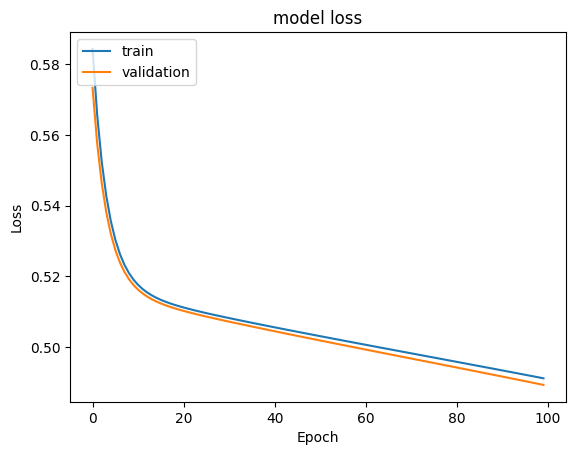

```python
#Plotting Train Loss vs Validation Loss
plt.plot(history_0.history['loss'])
plt.plot(history_0.history['val_loss'])
plt.title('model loss')
plt.ylabel('Loss')
plt.xlabel('Epoch')
plt.legend(['train', 'validation'], loc='upper left')
plt.show()
```

#### Recall

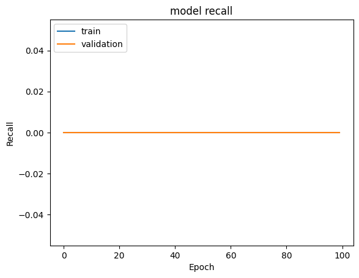

```python
#Plotting Train recall vs Validation recall
plt.plot(history_0.history['recall'])
plt.plot(history_0.history['val_recall'])
plt.title('model recall')
plt.ylabel('Recall')
plt.xlabel('Epoch')
plt.legend(['train', 'validation'], loc='upper left')
plt.show()
```

```python
#Predicting the results using best as a threshold
y_train_pred = model_0.predict(X_train)
y_train_pred = (y_train_pred > 0.5)
```

```python
#Predicting the results using best as a threshold
y_val_pred = model_0.predict(X_val)    ## code to make prediction on the validation set
y_val_pred = (y_val_pred > 0.5)
```

```python
model_name = "NN with SGD"

train_metric_df.loc[model_name] = recall_score(y_train, y_train_pred)  ## adding recall values to the datatable
valid_metric_df.loc[model_name] = recall_score(y_val, y_val_pred)      ## adding recall values to the datatable
```

#### Classification Report

```python
#lassification report
cr = classification_report(y_train, y_train_pred)
print(cr)
```

```
              precision    recall  f1-score   support

           0       0.80      1.00      0.89      6370
           1       0.00      0.00      0.00      1630

    accuracy                           0.80      8000
   macro avg       0.40      0.50      0.44      8000
weighted avg       0.63      0.80      0.71      8000
```

```python
#classification report for validatoin set
cr=classification_report(y_val, y_val_pred)    ## code to check the model's performance on the validation set
print(cr)
```

```
              precision    recall  f1-score   support

           0       0.80      1.00      0.89       796
           1       0.00      0.00      0.00       204

    accuracy                           0.80      1000
   macro avg       0.40      0.50      0.44      1000
weighted avg       0.63      0.80      0.71      1000
```

#### Confusion Matrix

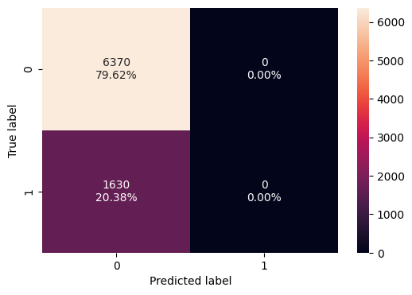

```python
make_confusion_matrix(y_train, y_train_pred) ## making confusion matrix
```

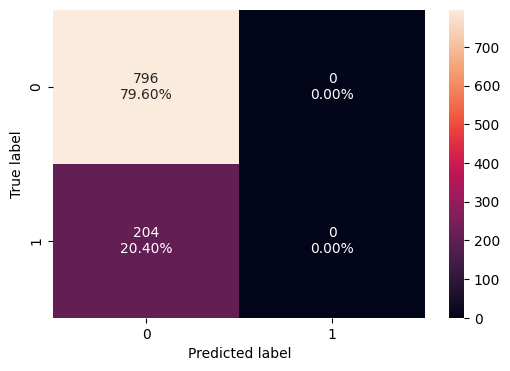

```python
make_confusion_matrix(y_val, y_val_pred)    ## code to check the model's performance on the validation set
```

## Model Performance Improvement

### Neural Network with Adam Optimizer

```python
backend.clear_session()
#Fixing the seed for random number generators so that we can ensure we receive the same output everytime
np.random.seed(1)
random.seed(1)
tf.random.set_seed(1)
```

```python
#Initializing the neural network
model_1 = Sequential()
# Adding the input layer with 64 neurons and relu as activation function
model_1.add(Dense(64, activation='relu', input_dim = X_train.shape[1]))
# add hidden layer with 16  neurons and sigmoid as activation
model_1.add(Dense(16, activation='sigmoid'))
# output layer with 1 neuron giving us output iwth sigmoid activation
model_1.add(Dense(1, activation = 'sigmoid'))
```

```python
#Complete the code to use Adam as the optimizer.
optimizer = tf.keras.optimizers.Adam(learning_rate=0.001)
metric = keras.metrics.Recall()
```

```python
##code to compile the model with binary cross entropy as loss function and recall as the metric
model_1.compile(loss='binary_crossentropy',optimizer=optimizer,metrics=[metric])
```

```python
model_1.summary()
```

```
Model: "sequential"
_________________________________________________________________
 Layer (type)                Output Shape              Param #
=================================================================
 dense (Dense)               (None, 64)                768

 dense_1 (Dense)             (None, 16)                1040

 dense_2 (Dense)             (None, 1)                 17

=================================================================
Total params: 1,825
Trainable params: 1,825
Non-trainable params: 0
_________________________________________________________________
```

```python
#Fitting the ANN
history_1 = model_1.fit(
    X_train,y_train,
    batch_size=64,
    validation_data=(X_val,y_val),
    epochs=100,
    verbose=1
)
```

#### Loss Function

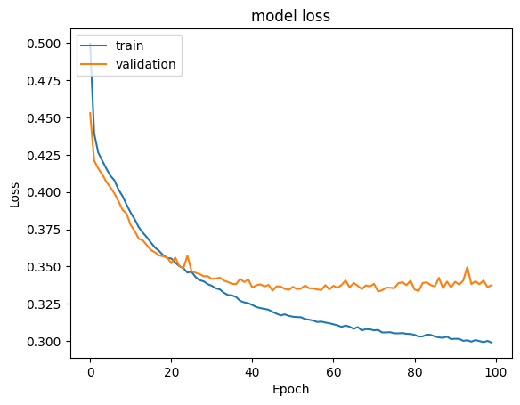

```python
#Plotting Train Loss vs Validation Loss
plt.plot(history_1.history['loss'])
plt.plot(history_1.history['val_loss'])
plt.title('model loss')
plt.ylabel('Loss')
plt.xlabel('Epoch')
plt.legend(['train', 'validation'], loc='upper left')
plt.show()
```

#### Recall

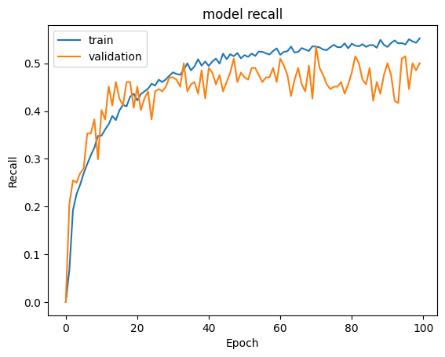

```python
#Plotting Train recall vs Validation recall
plt.plot(history_1.history['recall'])
plt.plot(history_1.history['val_recall'])
plt.title('model recall')
plt.ylabel('Recall')
plt.xlabel('Epoch')
plt.legend(['train', 'validation'], loc='upper left')
plt.show()
```

```python
#Predicting the results using 0.5 as the threshold
y_train_pred_1=model_1.predict(X_train)
y_train_pred_1 = (y_train_pred > 0.5)
```

```python
#Predicting the results using 0.5 as the threshold
y_val_pred_1=model_1.predict(X_val)
y_val_pred_1= (y_val_pred_1 > 0.5)
```

#### Classification Report

```python
#lassification report
cr=classification_report(y_train,y_train_pred_1)
print(cr)
```

[output not shown]

```python
#classification report
cr=classification_report(y_val,y_val_pred_1)  ## Complete the code to check the model's performance on the validation set
print(cr)
```

```
              precision    recall  f1-score   support

           0       0.88      0.96      0.92       796
           1       0.76      0.50      0.60       204

    accuracy                           0.86      1000
   macro avg       0.82      0.73      0.76      1000
weighted avg       0.86      0.86      0.85      1000
```

#### Confusion matrix

[figure not shown]

```python
#Calculating the confusion matrix
make_confusion_matrix(y_train, y_train_pred_1)
```

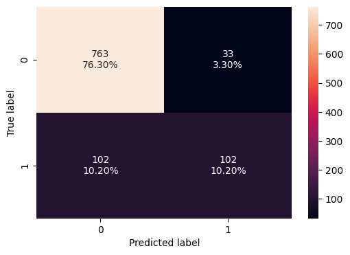

```python
#Calculating the confusion matrix
make_confusion_matrix(y_val,y_val_pred_1)  ## Complete the code to check the model's performance on the validation set
```